# Dropping Darts on a Rug

An Introduction to Probability

Ben Woodruff

March 05, 2021

We’ll need the following libraries and functions to evaluate the examples in this file.

```r
library(knitr)

#We can discuss the names of functions once we have them all.  It might be best to use
#draw_pmf
#draw_rug
#draw_rect_approx
draw_pmf <- function(x,p){
  xs <- c(rbind(x-1/2,x-1/2,x+1/2,x+1/2))
  px <- c(rbind(0,p,p,0))
  par(mar=c(2.5,2.5,0.25,0.25))
  plot.new()
  plot(xs,px,type="l")
  polygon(xs,px,col="gray")
}

draw_rug <- function(f,a,b,num_points=100){
  x <- c(a,seq(a,b,(b-a)/num_points),b,a)
  y <- c(0,f(seq(a,b,(b-a)/num_points)),0,0)
  par(mar=c(2.5,2.5,0.25,0.25))
  plot(x,y,type = "l")
  polygon(x,y,col="gray")
}

draw_rect_approx <- function(f,a,b,num_rectangles){
  n <- num_rectangles
  dx <- (b-a)/n
  x <- c(a,seq(a,b,dx/100),b,a)
  y <- c(0,f(seq(a,b,dx/100)),0,0)
  par(mar=c(2.5,2.5,0.25,0.25))
  plot(x,y,type = "l")
  xi <- seq(a+dx/2,b,dx)
  lines(xi-dx/2,f(xi),type = "h")
  lines(xi-dx/2,f(xi),type = "s")
  lines(c(xi[n]-dx/2,xi[n]+dx/2),f(c(xi[n],xi[n])),type = "l")
  lines(c(xi[n]-dx/2,xi[n]+dx/2),f(c(xi[n],xi[n])),type = "h")
}
```

## Day 1: Means, Expected Value, And Discrete Random Variables.

### Averaging Test Scores

1. We can compute the mean by adding 11 numbers together and dividing by the number of scores. This gives
   $$\bar x=\frac{\sum \text{value}}{\text{number of values}} = \frac{70+70+70+85+85+85+85+85+ 90+95+95}{11}\approx 83.18.$$
2. We can compute the numerator of the fraction in the previous part by multiplying each score by how many times it occurs, rather than adding it in the sum that many times. This gives
   $$\bar x=\frac{\sum (\text{value}\cdot\text{weight})}{\sum \text{weight}} = \frac{70(3)+85(5)+90(1)+95(2)}{3+5+1+2}\approx 83.18.$$
3. We can compute $\bar x$ by splitting up the fraction in the previous part into the sum of four numbers. We call this a ``weighted average’’ because we are multiplying each score by a weight. Note that the sum of the weights is 1, as each weight is a proportion of the total scores. This gives
   $$\bar x=\sum (\text{value}\cdot\text{(% of stuff)}) = 70\frac{3}{11}+85\frac{5}{11}+90\frac{1}{11}+95\frac{2}{11}\approx 83.18.$$

#### Exercises

1. Consider the vector of integers c(2,2,2,3,3,5,5,5,5,7,8,8,9).
   1. Find the mean of the values by summing the values and then dividing by the number of values.
   2. Use the values vector c(2,3,5,7,8,9) and frequencies vector c(3,2,4,1,2,3) to compute the mean of integers.
   3. Use the values vector c(2,3,5,7,8,9) and proportions vector c(3/15,2/15,4/15,1/15,2/15,3/15) to compute the mean of integers.
2. Contruct your own vector, and write code that computes the mean of the values in the vector using each of the 3 methods in this section.

### Balancing point, Center-of-mass, Centroid

Have you ever sat on a seesaw with someone whose weight is quite different than yours? Maybe you’ve tried balancing something with your finger? To find the right place to sit on the seesaw, or to find the correct balancing point, we need is to locate the center-of-mass of a system.

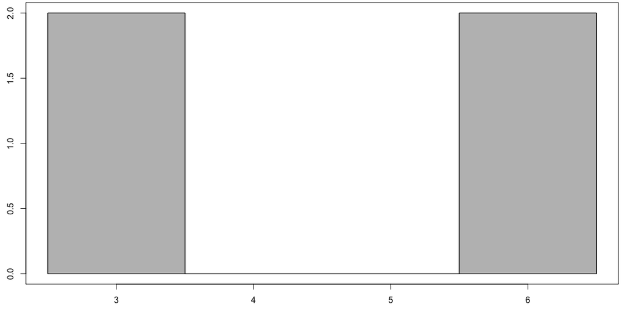

```r
x <- c(3,6)
num <- c(2,2)
draw_pmf(x,num)
```

How does the picture above change if the weights (areas) of the two objects are different? Suppose the first rectangle has an area of $A_1= 2$ centered at $x_1=3$, and the second object has an area of $A_2=4$ centered at $x_2=6$ (see the image below).

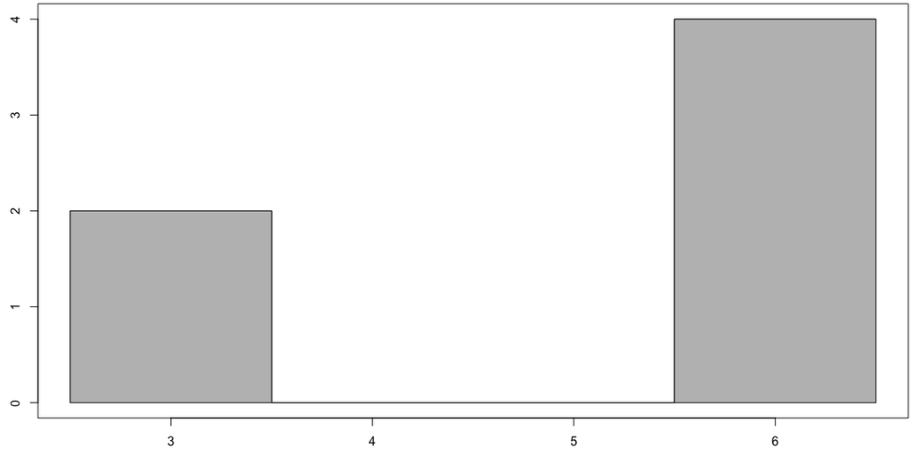

```r
x <- c(3,6)
num <- c(2,4)
draw_pmf(x,num)
```

Remember that we’ve imagined the $x$-axis as a tray holding these rectangles up. If we placed our finger under the point $x=4.5$, the larger rectangle would cause the tray to tilt to the right. At what point $\bar x$ would we place our finger to balance the system? We call this point the centroid of the system (technically this will only give us the $x$-coordinate of the centroid, but we’ll continue to refer to it as the centroid).

- One way to tackle this problem is to think of the first rectangle as being two 1 by 1 rectangles, and second rectangle as four 1 by 1 rectangles. This means we have 6 total rectangles all with the same area. Note that $n_1=2$ of these rectangles are centered at $x_1=3$, while $n_2 =4$ of the rectangles are located at $x_2=6$. We can just average together these 6 values, in any of the ways done in the previous section, to obtain
  $$\bar x = \frac{3+3+6+6+6+6}{6} = \frac{3(2)+6(4)}{6} = 3\left(\frac{2}{6}\right)+6\left(\frac{4}{6}\right)=5.$$

If we place our finger under the $x$-axis at the centroid $\bar x = 5$, then the system is perfectly balanced.

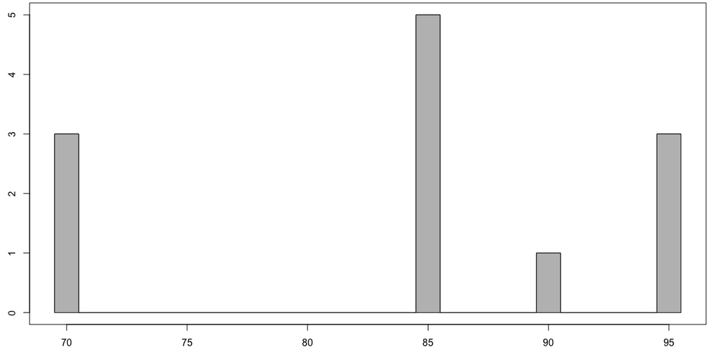

```r
x <- c(70,85,90,95)
num <- c(3,5,1,3)
draw_pmf(x,num)
```

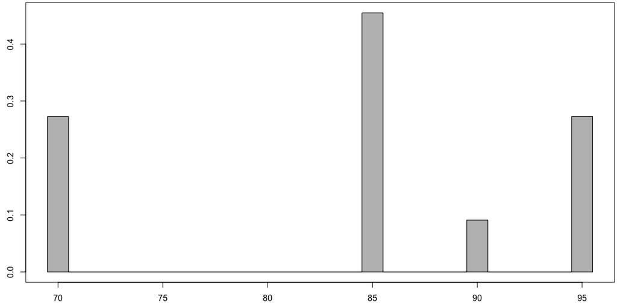

```r
x <- c(70,85,90,95)
num <- c(3/11,5/11,1/11,3/11)
draw_pmf(x,num)
```

If we ignore the $y$-axis, this second image looks almost identical to the first, and has the exact same centroid along the $x$-axis. With a total area of $\sum A_i = 1$, the centroid formula simplifies to
$$\bar x = \frac{\sum x_i A_i}{\sum A_i} = \frac{\sum x_i A_i}{1} = \sum x_i A_i.$$
We use the word centroid when referring to a geometric center. In the next section, we’ll start calling this the expected value of a random variable, written $\mu$ or $E[X]$.

#### Exercises

1. Find centroid of 2 rectangles centered at $x_1=-1$ and $x_2=3$ with corresponding areas $A_1=7$ and $A_2=2$.
2. Find centroid of 4 rectangles centered at $x$-values 0,1,2,3 with correponding areas 1,3,3,1.
3. Find centroid of 6 rectangles centered at $x$-values 1,2,3,4,5,6 with areas 1,2,3,4,5,6.
4. Repeat the three previous exercises by first turning the areas into proportions. For example, the first problem consists of 2 rectangles centered at -1,3 with areas 7/9,2/9.

Each of these exercises computes an expected value for the next section.

### Discrete Random Variables

Let’s turn our attention to discrete random variables and probability. We’ll see that the centroid discussed above gives us additional insight into understanding random variables.

### Tossing a coin three times and counting heads

Suppose we toss a coin three times and record the number of heads. Let the random variable $X$ represent this total number of heads.Note that possible outcomes of counting the number of heads are $0,1,2,3$ (these are discrete values, hence we call this a discrete random variable). These outcomes arise from the 8 possible results of tossing a coin three times (TTT,TTH,THT, THH,HTT,HTH,HHT, HHH).

- There is only one way to get 0 heads (toss 3 tails in a row) which means the outcome of 0 heads has a probability of $P(X=0) = \frac{1}{8} = 0.125$.
- Similarly, there is only one way to get 3 heads which means $P(X=3) = \frac{1}{8} = 0.125$.
- There are three ways to get 1 head, and 3 ways to get 2 heads, which means $P(X=1) = P(X=2) = \frac{3}{8} = 0.375$.

This gives us a function (called a probability mass function) which we can summarize in the table and graphs below.

```r
x <- c(0,1,2,3)
p <- c(1/8,3/8,3/8,1/8)
tbl <- data.frame(outcome=x, probability = p )
kable(tbl, format = "html", align = "c")
```

| outcome | probability |
| --- | --- |
| 0 | 0.125 |
| 1 | 0.375 |
| 2 | 0.375 |
| 3 | 0.125 |

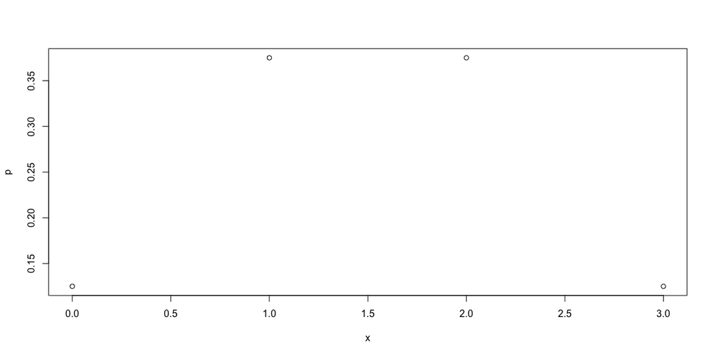

```r
plot(x,p)
```

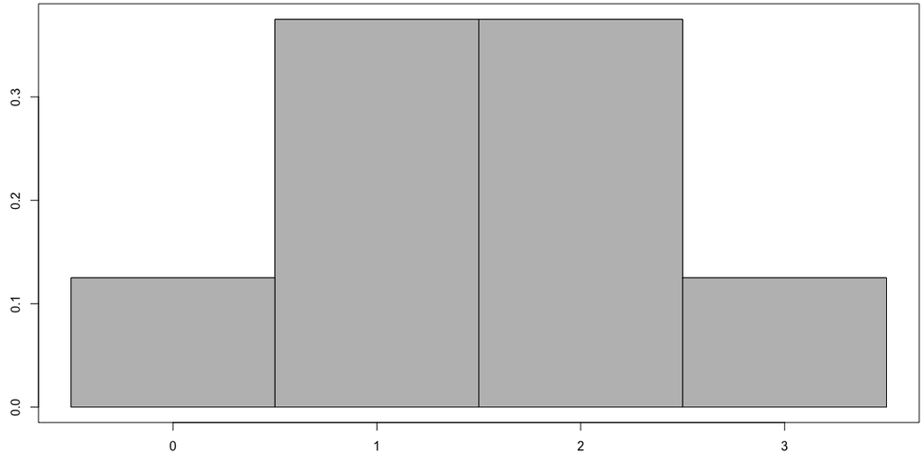

```r
draw_pmf(x,p)
```

Note that in the graph above, we’ve given each rectangle a width of 1 unit so that areas match probabilities. To connect this theoretical model to something physical, we can think of this graphical representation as a rug, made by sewing 4 different length rectangles to the $x$-axis. The centroid of said rug is located directly in the center of the graph at $x=1.5$. We can obtain this via the computation
$$\bar x = \sum x_i A_i = 0(\frac{1}{8})+1(\frac{3}{8})+2(\frac{3}{8})+3(\frac{1}{8}) = 1.5.$$

We computed the above in the context of a physical rug, and the word centroid and symbol $\bar x$ are appropriate in this context. For a random variable, the vocabulary and notation change, but the computations are the same.

> The **expected value** of a discrete random variable $X$ with outcomes $x_i$ having probability $p_i$ is given by
> $$\mu = E[X] = \sum x_i p_i.$$

We compute the expected value below for the random variable $X$ representing tossing 3 coins and counting the number of heads.

```r
x <- c(0,1,2,3)
p <- c(1/8,3/8,3/8,1/8)
sum(x*p)
```

```
## [1] 1.5
```

The expected value of a random variable provides a measure of what would happen if we repeated something many times, and then averaged the results. If we were to run this experiment 8 million times, then about 1 million times we would have 0 heads, 3 million times we’d have 1 head, 3 million times we’d have 2 heads, and 1 million times we’d have 3 heads. The mean of these values is
$$\bar x = 0(\frac{1000000}{8000000}) + 1(\frac{3000000}{8000000}) + 2(\frac{3000000}{8000000}) + 3(\frac{1000000}{8000000}).$$
This simplifies to the same computation we had before, resulting in $\bar x = 1.5$ When we write $\mu$ or $E[x]$ instead of $\bar x$, we’re referring to a distribution average. We can think of this as a limit of averages as we increase the number of times we repeat an experiment. We use $\bar x$ to represent a sample mean (or mean of the data) and $\mu$ to represent the population mean (or mean of the distribution).

Before we move on to the next example, let’s pause and notice another key fact about all discrete random varibles.

The process above, of computing the probability that a random variable takes on any value less than or equal to some given value, is so common that we’ve given it a name and most software programs have a simple way to compute it.

> The **cumulative distribution function** (CDF) of a random variable $X$ is the function $F(x) = P(X\leq x)$. It computes the probability that $X$ takes on a value less than or equal to $x$. We’ll often use a capital $F$ to denote the CDF of $X$.

Above we computed $F(2)$. We can use the cumsum() function in R to rapidly compute the CDF at a few value for this discrete random variable, and then display the results in the table below.

```r
x <- c(0,1,2,3)
p <- c(1/8,3/8,3/8,1/8)
cdf <- cumsum(p)
tbl <- data.frame(outcome=x, probability = p, CDF = cdf )
kable(tbl, format = "html", align = "c")
```

| outcome | probability | CDF |
| --- | --- | --- |
| 0 | 0.125 | 0.125 |
| 1 | 0.375 | 0.500 |
| 2 | 0.375 | 0.875 |
| 3 | 0.125 | 1.000 |

#### Exercises

1. Verify by hand that $F(1) = 0.5$.
2. Locate $F(2)$ in the table above.
3. Compute $F(1.7)$. Explain.
4. What is $F(3)$? Give several reasons for your answer.
5. The table tells us $F(0) = 0.125$. Compute $P(X>0)$ using this fact.

### Rolling two dice and summing them

We now let $X$ be the discrete random variable obtained by rolling two 6-sided dice and recording their sum. The possible outcomes are the integers from 2 up to 12. (If you’ve played Settler’s of Catan before, then the dots on the number cards provide a visual of the probability mass function). There are 36 results for rolling two six-sided fair dice, and the probability mass function for $X$ is given in the table and diagram below.

```r
x <- seq(2,12)
p <- c(1/36,2/36,3/36,4/36,5/36,6/36,5/36,4/36,3/36,2/36,1/36)
tbl <- data.frame(outcome=x, prob = p)
kable(tbl, format = "html", align = "c")
```

| outcome | prob |
| --- | --- |
| 2 | 0.0277778 |
| 3 | 0.0555556 |
| 4 | 0.0833333 |
| 5 | 0.1111111 |
| 6 | 0.1388889 |
| 7 | 0.1666667 |
| 8 | 0.1388889 |
| 9 | 0.1111111 |
| 10 | 0.0833333 |
| 11 | 0.0555556 |
| 12 | 0.0277778 |

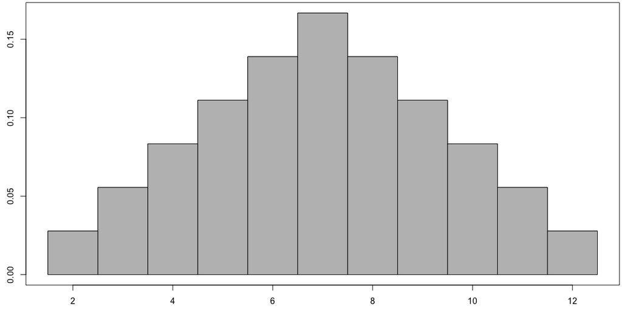

```r
draw_pmf(x,p)
```

#### Exercises

1. What is the expected value of this random variable? Try to spot the value both visually (locating a centroid) and the verify your computation is correct using $\mu = \sum x_ip_i$.
2. Recall that $F(x) = P(X\leq x)$ is the cumulative distribution function for $X$. Compute $F(x)$ for each $x$ from 2 up to 12.
3. Why do we know $F(12)=1$.
4. What is $F(15)$?
5. State $P(X\leq 4)$ and $P(X\leq 9)$ from the CDF table. Explain why $P(4<X\leq 9)= P(X\leq 9)-P(X\leq 4)$.

Some Solutions: The table below provides some of the values of the CDF of $X$.

```r
x <- seq(2,12)
p <- c(1/36,2/36,3/36,4/36,5/36,6/36,5/36,4/36,3/36,2/36,1/36)
cdf <- cumsum(p)
tbl <- data.frame(outcome=x, prob = p, CDF = cdf)
kable(tbl, format = "html", align = "c")
```

| outcome | prob | CDF |
| --- | --- | --- |
| 2 | 0.0277778 | 0.0277778 |
| 3 | 0.0555556 | 0.0833333 |
| 4 | 0.0833333 | 0.1666667 |
| 5 | 0.1111111 | 0.2777778 |
| 6 | 0.1388889 | 0.4166667 |
| 7 | 0.1666667 | 0.5833333 |
| 8 | 0.1388889 | 0.7222222 |
| 9 | 0.1111111 | 0.8333333 |
| 10 | 0.0833333 | 0.9166667 |
| 11 | 0.0555556 | 0.9722222 |
| 12 | 0.0277778 | 1.0000000 |

The expected value is computed below.

```r
x <- seq(2,12)
p <- c(1/36,2/36,3/36,4/36,5/36,6/36,5/36,4/36,3/36,2/36,1/36)
sum(x*p)
```

```
## [1] 7
```

### Avoid Gambling

Gambling can be phrased in terms of probability. We can mathematically give a reason why gambling is a bad idea. As a humor aside, in *The True Meaing of Smekday* by Adam Rex (the book behind DreamWorks Animation’s 2015 movie *Home*), we find the quote

> At one point, an alien searching for a casino shouts: “I WAS TOLD TO GO TO THE LARGE OFFENSIVELY COLORED BUILDING WHERE HUMANS WHO ARE BAD AT MATH GIVE AWAY THEIR MONEY.”

Here’s a simple gambling game we’ll explore. You pay 1 dollar to play. Your roll two dice and multiply the result together. If you roll a product of 20 or more, you get $4 (your dollar back, plus 3 more). Otherwise, you get nothing (you lost a dollar). There are two outcomes, namely you lose a buck, or you gain 3 bucks. We’ll let $X$ be the random variable with outcomes of $-1$ and $3$ resulting from this game.

To get a probabiliy mass function, we need the probability of getting a product of 20 or above. Let $Y$ be the random variable which is the product of rolling two dice. The probability mass function for $Y$ is shown below.

```r
x <- c(1,2,3,4,5,6,8,9,10,12,15,16,18,20,24,25,30,36)
p <- c(1/36,2/36,2/36,3/36,2/36,4/36,2/36,1/36,2/36,4/36,2/36,1/36,2/36,2/36,2/36,1/36,2/36,1/36)
cdf <- cumsum(p)
tbl <- data.frame(outcome=x, prob = p, CDF = cdf)
kable(tbl, format = "html", align = "c")
```

| outcome | prob | CDF |
| --- | --- | --- |
| 1 | 0.0277778 | 0.0277778 |
| 2 | 0.0555556 | 0.0833333 |
| 3 | 0.0555556 | 0.1388889 |
| 4 | 0.0833333 | 0.2222222 |
| 5 | 0.0555556 | 0.2777778 |
| 6 | 0.1111111 | 0.3888889 |
| 8 | 0.0555556 | 0.4444444 |
| 9 | 0.0277778 | 0.4722222 |
| 10 | 0.0555556 | 0.5277778 |
| 12 | 0.1111111 | 0.6388889 |
| 15 | 0.0555556 | 0.6944444 |
| 16 | 0.0277778 | 0.7222222 |
| 18 | 0.0555556 | 0.7777778 |
| 20 | 0.0555556 | 0.8333333 |
| 24 | 0.0555556 | 0.8888889 |
| 25 | 0.0277778 | 0.9166667 |
| 30 | 0.0555556 | 0.9722222 |
| 36 | 0.0277778 | 1.0000000 |

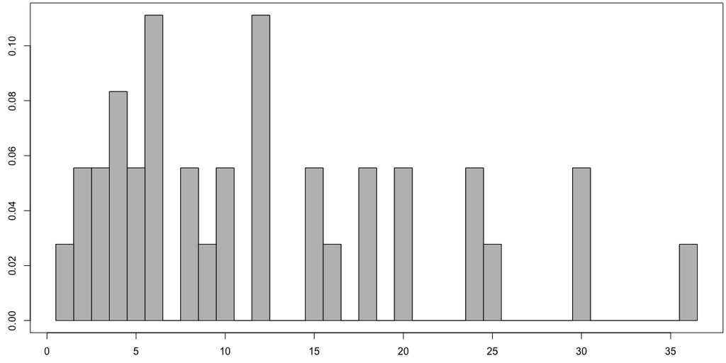

```r
draw_pmf(x,p)
```

From the table above, we quickly see that $F_Y(18) = P(Y\leq 18)= 0.777778$, with exact value $F_Y(18) = \frac{7}{9}$. Because 19 is not a possible product of two dice, we know that
$$P(Y\geq 20)=1-P(Y<20) =1-P(Y\leq 18)= 1-\frac79 = 2/9.$$

We now have the details we need to examine the gambling game represented by the random variable $X$, since we now have $P(X=-1) = \frac{7}{9}$ and $P(X=3) = \frac{2}{9}$.

#### Exercises

1. Verify that for $X$, the sum of the probabilities is 1.
2. Give the probability mass function for $X$ as a table and as a rug diagram (draw it by hand, then verify the result using code from above).
3. Compute the expected value of $X$. (Solution: $\mu = E[X] = -0.11\bar 1$). This means that if you play the game many times, you can expect to lose on average about 11 cents each game. Casinos make money because they arrange the games to guarantee a negative expected value for the people playing. Yes, occasionally someone will walk away having won more than they paid (which the casino wants advertised), but the truth is that when you look at the long term average of all played games, the casino comes out ahead.
4. Compute $E[Y]$. (This isn’t needed to answer the gambling question, but $Y$ is it’s own random variable and has its own expected value.)

The code below can be used to help you verify your work above.

```r
x <- c(-1,3)
p <- c(7/9,2/9)
cdf <- cumsum(p)
tbl <- data.frame(outcome=x, prob = p, CDF = cdf)
kable(tbl, format = "html", align = "c")
```

| outcome | prob | CDF |
| --- | --- | --- |
| -1 | 0.7777778 | 0.7777778 |
| 3 | 0.2222222 | 1.0000000 |

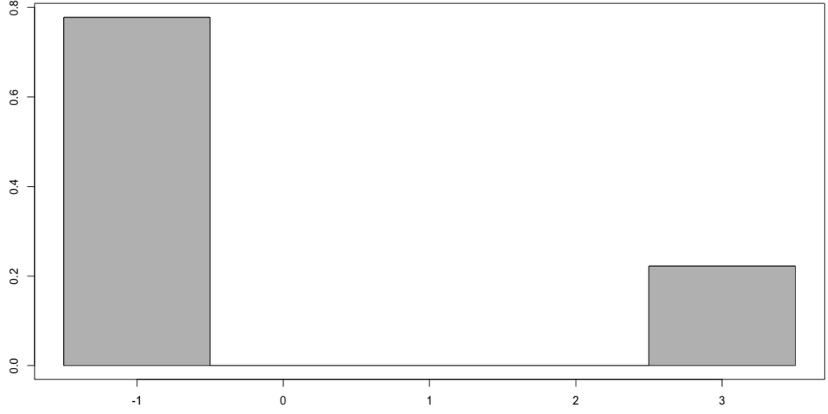

```r
draw_pmf(x,p)
```

```r
c(sum_of_prob = sum(p), expected_value = sum(x*p))
```

```
##    sum_of_prob expected_value
##      1.0000000     -0.1111111
```

### How many hurricanes - Poisson

This section is still in rough draft form. It needs definitions. To be done.

We’ll look at another example related to the hurricane example we did earlier this semester. This follows a Poison distribution.

```r
lambda <- 5.857143
x <- seq(0,100)
p <- lambda^x *exp(-lambda)/factorial(x)
cdf <- cumsum(p)
n <-10
data.frame(outcome=x[1:n], prob = p[1:n], cdf = cdf[1:n])
```

```
##    outcome        prob         cdf
## 1        0 0.002859401 0.002859401
## 2        1 0.016747923 0.019607324
## 3        2 0.049047489 0.068654812
## 4        3 0.095759385 0.164414197
## 5        4 0.140219102 0.304633300
## 6        5 0.164256667 0.468889966
## 7        6 0.160345798 0.629235764
## 8        7 0.134166895 0.763402659
## 9        8 0.098229336 0.861631996
## 10       9 0.063927030 0.925559026
```

```r
sum(x*p)
```

```
## [1] 5.857143
```

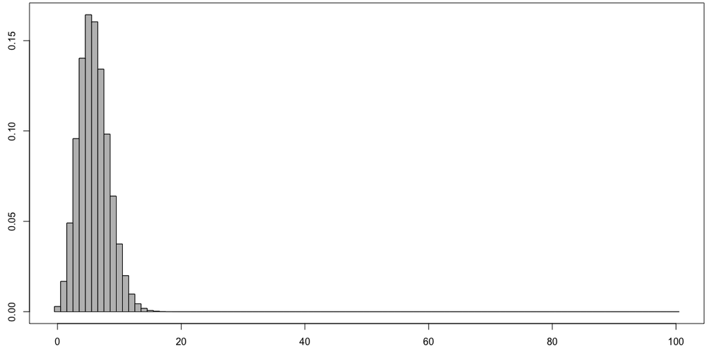

```r
draw_pmf(x,p)
```

####Exercises

1. Compute $E[X]$.

### Rolling a single fair die

Roll a single 6 sided die and record the value. We can visually see the middle of the rug is at 3.5, once we draw the rug. Note that the height must be 1/6 for the total area to be 1.

```r
x <- seq(1,6)
p <- rep(1/6,6)
cdf <- cumsum(p)
data.frame(outcome=x, prob = p, cdf = cdf, x.p = (x*p))
```

```
##   outcome      prob       cdf       x.p
## 1       1 0.1666667 0.1666667 0.1666667
## 2       2 0.1666667 0.3333333 0.3333333
## 3       3 0.1666667 0.5000000 0.5000000
## 4       4 0.1666667 0.6666667 0.6666667
## 5       5 0.1666667 0.8333333 0.8333333
## 6       6 0.1666667 1.0000000 1.0000000
```

```r
sum(x*p)
```

```
## [1] 3.5
```

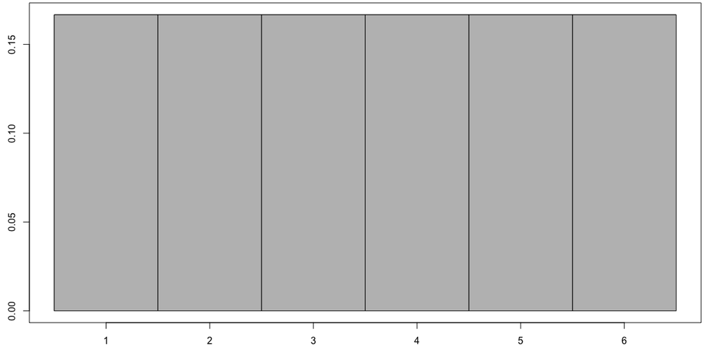

```r
draw_pmf(x,p)
```

### Rolling a single weighted die

Maybe include as extra? Warp into an exercise?

```r
x <- seq(1,6)
p <- c(1/21,2/21,3/21,4/21,5/21,6/21)
cdf <- cumsum(p)
data.frame(outcome=x, prob = p, cdf = cdf, x.p = (x*p))
```

```
##   outcome       prob        cdf        x.p
## 1       1 0.04761905 0.04761905 0.04761905
## 2       2 0.09523810 0.14285714 0.19047619
## 3       3 0.14285714 0.28571429 0.42857143
## 4       4 0.19047619 0.47619048 0.76190476
## 5       5 0.23809524 0.71428571 1.19047619
## 6       6 0.28571429 1.00000000 1.71428571
```

```r
sum(x*p)
```

```
## [1] 4.333333
```

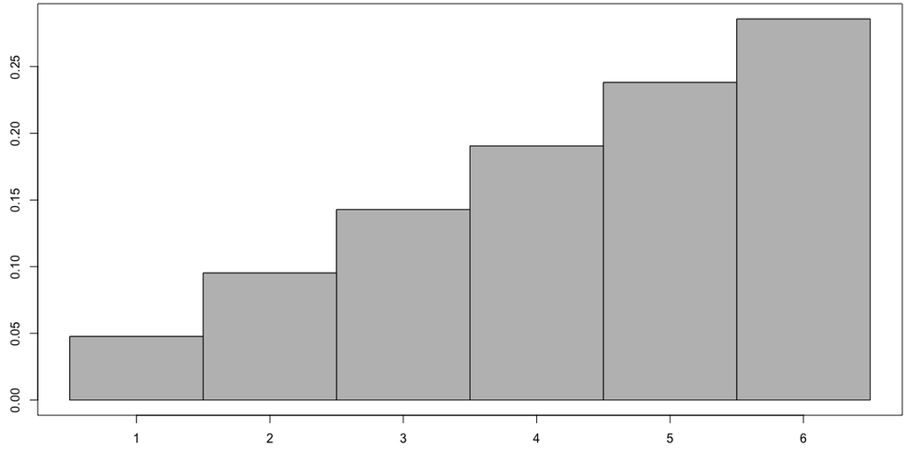

```r
draw_pmf(x,p)
```

## Day 2: Rugs for Continous Random Variables

### A Rectangular Rug

In the discrete probability (random variable) examples above, we were able to attach a probability to each individual event. Our goal now is to generalize what we did above to work with continuous probabilities. We can actually reframe every probabilty problem into the context of dropping a dart at a random spot on a rug. The rug diagrams we construct will be very similar to the ones in the discrete case, but the computational approach will change.

Let’s suppose for a minute that we have a rug (as shown below) and a trap door on the ceiling above the rug.

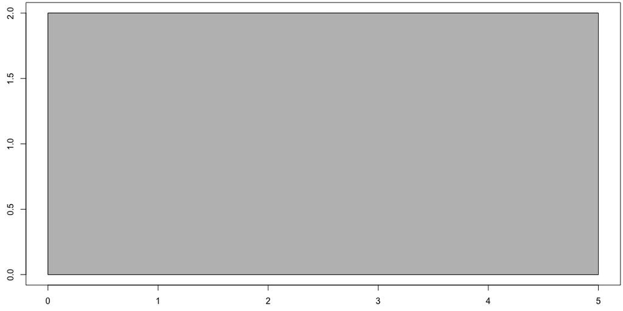

```r
f <- function(x){2+x*0}
draw_rug(f,0,5)
```

Each time we open the trap door, a dart falls from above to a random spot on the rug. Assume the rug is oriented on the coordinate plane with the lower left corner at the origin and the bottom side of the rug along the $x$-axis. (We will always think of our rugs as having the bottom side of the rug along the $x$-axis.) Each point on the rug has the same probability of being hit as any other.

When a dart falls on the point $(x,y)$, we’ll record just the $x$-coordinate (so a number between 0 and 5), and let $X$ represent this random variable.

- Give several different possible outcomes for $X$. How many outcomes are there?
- Compute each of the following probabilities, and explain how you obtained your answer by comparing areas.
  - $P(X \leq 1)$
  - $P(X \leq 3)$
  - $P(X \leq 7)$
  - $P(X \leq -1.5)$
  - $P(1 \leq X \leq 5)$
  - $P(1 \leq X \leq 3)$
- Change the height of the rug from 2 to 3. Then verify that each of the computations above result in the same probability.
- If the area of the rug is 1, then we can skip dividing by area when computing probabilities. The function describing the top of the rug is currently $f(x) = 2$, and the total area under the rug is $A=10$. We can multipy a function by a constant $k$ so that the rug under $kf(x)$ has area 1. We’ll call this the normalized rug function. Explain why we want $k=1/10$ in this problem, which means our normalized rug function is $f(x) = \frac{1}{10}2 = \frac{1}{5}$.
  - For a rug with area $A$ whose top is defined by the function $f(x)$, what value should we choose for $k$ so that the rug under $kf(x)$ has area 1? (this will be best later on - not here.)
- Given an $x$-value, the cumulative distribution function, written $F(x)$, for the random variable $X$ will compute the probability that $X$ takes on any value up to and including $x$. For example, above we computed $F(1) = P(X\leq 1) = 0.2$ and $F(3) = P(X \leq 3) = 0.6$.
  - Compute $P(X \leq 2)$
  - If $0<x<5$, explain why $P(X \leq x) = x/5$.
  - If $x<0$, why does $P(X\leq x)=0$?
  - If $x>5$, what is $P(X\leq x)$? (You should get a number.) Explain.
- We have $F(x)=\begin{cases}0&x<0\\x/5&0\leq x\leq 5\\1&x>5\end{cases}$. Compute the derivative of $F(x)$ and compare it to the normalized rug function.
- Imagine that we dropped 1000 darts on this rug, and recorded each of their $x$ values. What would the mean $x$ value be? Explain.

We can use a simulation to analyze the last question. Below we pick 1000 random numbers between 0 and 5, and then find their mean. We can also view the first 10 numbers, just to verify that they are not discrete integers, but rather take on any value between 0 and 5 (which is why we call this a continuous random variable).

```r
n <- 1000
x <- runif(n, min = 0, max = 5)
x[1:10]
```

```
##  [1] 4.845550081 2.865033386 1.939811539 0.663737885 2.350212079 1.858532692
##  [7] 3.079466975 4.358475107 1.618969273 0.009987422
```

```r
mean(x)
```

```
## [1] 2.489473
```

```r
n <- 1000000
x <- runif(n, min = 0, max = 5)
mean(x)
```

```
## [1] 2.502866
```

We computed the mean $x$-value in several samples. As the sample size increases, the mean approaches a limit, which we call the expected value of the random variable, and denote using both $E[X]$ and $\mu$. The expected value gives us a way of discussing a theoretical mean when the possible outcomes is infinite.

For this rectangular rug, notice that the centroid (geometric center) of the rug is at the point $(x,y) = (2.5,1)$. The fact that the expected value of our random variable $X$ matched the $x$-coordinate of the centroid of our rug is more than just a coincidence. In general, we can find the expected value of a random variable by obtaining the geometric center.

We chose a rectangular rug to start with for a reason. Many connections to geometry will generalize quickly as we move away from a rectangular rug. Here are some key points.

- Probabilities and area computations are directly connected.
- The cumulative distribution function gives a ratio of areas to the left of a desired spot, divided by the total area of the rug.
- If we pick a value $k$ to that the total area under $kf(x)$ is one, then we can compute probabilities by just computing an area (no division needed)
- Expected value can be found by locating the x coordinate of the centroid.

### A Triangular Rug

We now swap to a triangular rug with a corresponding trap door on the ceiling above the rug. The rug is shown below, and lies below the function $f(x) = x$ for $0\leq x\leq 5$.

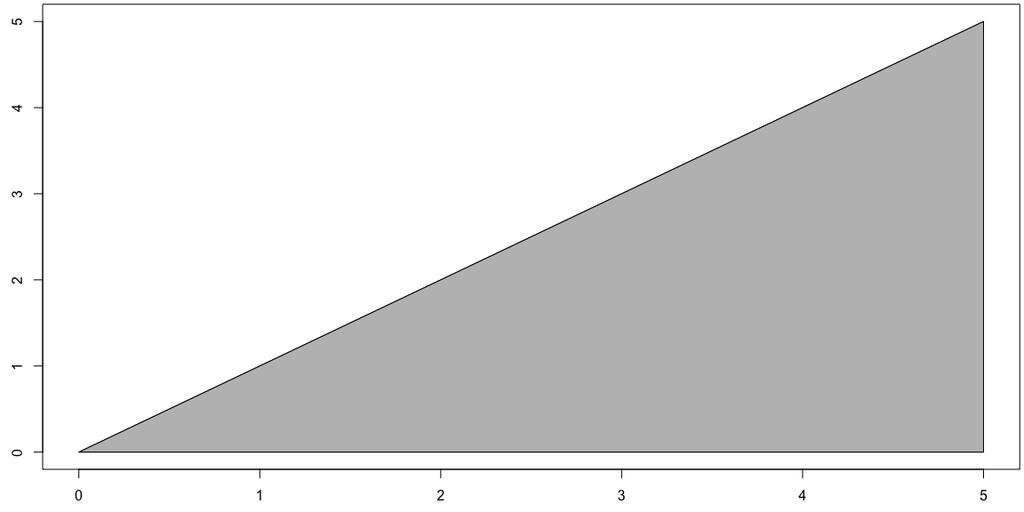

```r
f <- function(x){x}
draw_rug(f,0,5)
```

Each time we open the trap door, a dart falls from above to a random spot on the rug where each point on the rug has the same probability of being hit as any other. When a dart falls on the point $(x,y)$, we’ll record just the $x$-coordinate (so a number between 0 and 5), and let $X$ represent this random variable.

1. What is the total area of the rug?
2. Explain why points on the right side of the rug are more likely to be hit by a dart than points on the left side of the rug?
   1. Explain why $P(X\leq 2.5) = 1/4$.
   2. Compute $P(X > 2.5)$.
3. Find a value $k$ so that the area of the rug that lies under the function $kf(x)$ is equal to 1. This is our normalized rug function. [Solution: $k=\frac{2}{25} = 0.08$. How does this connect to the first question. ]
4. The fact that $P(X\leq 2.5) = 1/4$ means the cumulative distribution function (CDF) of $X$ has the value
   $$F(2.5) = P(X\leq 2.5) = \frac{1}{4}.$$
   1. Verify that $F(1) = \frac{1}{25}$ and $F(2)=\frac{4}{25}$.
   2. Compute $F(3)$ and $F(4)$.
   3. What are $F(5)$ and $F(6)$?
   4. For $0\leq x\leq 5$, explain why $F(x) = \frac{x^2}{25}$.
   5. If $x<0$, explain why $F(x)=0$.
   6. If $x>5$, explain why $F(x)=1$.
5. Give a formula for $F(x)$ using piecewise function notation Then compute the derivative of $F(x)$ and compare your answer to the normalized rug function $kf(x)$.
6. We have already seen that it’s more likely for the dart to land on the right side the rug than the left. The centroid of the rug (geometric center) also lies to the right. We can look up the centroid of a right triangle from various sources online (for examples Wikipedia has a [list of centroids](https://en.wikipedia.org/wiki/List_of_centroids)). Use such a list to explain why the x coordinate of the centroid of this right triangular rug is $\frac{10}{3} \approx 3.333$.
7. State $E[X]$.

### A Parabolic Rug

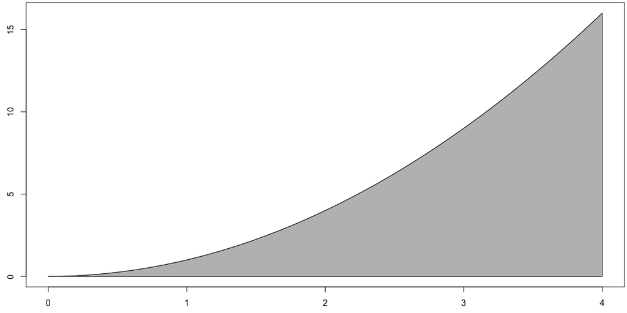

```r
f <- function(x){x^2}
draw_rug(f,0,4)
```

Again, each time we open the trap door, a dart falls from above to a random spot on the rug where each point on the rug has the same probability of being hit as any other. When a dart falls on the point $(x,y)$, we’ll record just the $x$-coordinate (so a number between 0 and 4), and let $X$ represent this random variable.

Download this [list of centroids of common shapes](https://www.bgu.ac.il/~yakhot/mf1/Centroids.pdf) from Engineering.com. The bottom of the first page include a parabolic spandrel (the shape of our rug above).

## Day 3: Rectanglar Approximations

Today we’ll focus on continuous random variables related to rugs that are formed by sewing together several rectangular rugs.

### Two rectangular rugs of different sizes.

Our next example is a rug that can be thought of as two different rugs, sewn together at $x=2.5$. One rug is 2.5 units wide by 2 units tall, while the other is 1.5 units wide by 4 units tall.

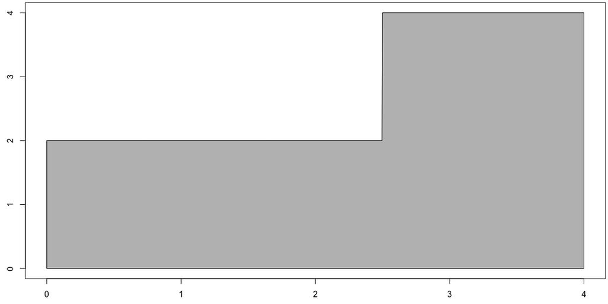

```r
f <- function(x){ifelse(x<2.5,2,4)}
draw_rug(f,0,4,num_points=1000)
```

```r
#The 1000 is needed to cause R to plot enough points
#to avoid a visual glitch with drawing
#piecewise defined functions.
#Increasing n here just
```

Again we’ll let the random variable $X$ be the $x$ coorinate of a dart that drops from the ceiling with an equal chance of hitting any point on the rugn.

Let’s start by computing the expected value of $X$. We can do so by finding the $x$-coordinate of the centroid of this rug? One option is to chop the rug into two two (split it at 2.5), find the centroid of each, and then use $\frac{\sum x_i A_i}{\sum A_i}$ to obtain the result.

- The left rug has a center of mass at $x_1=\frac{2.5-0}{2} = 1.25$, with an area of $A_1=hw=(2)(2.5)=5$.
- The right rug has a center of mass at $x_2=\frac{4-2.5}{2}=3.25$, with an area of $A_2=hw=(4)(1.5)=6$.

We then compute the center of mass of the two rugs, shown below.

```r
xi <- c(1.25,3.25)
Ai <- c(5,6)
c(total_area =sum(Ai),
  expected_value = sum(xi*Ai)/sum(Ai))
```

```
##     total_area expected_value
##      11.000000       2.340909
```

Another option is to chop the rug into 8 rugs with equal width, shown below. Note that the width of each rectangle is $\Delta x = \frac{4}{8} = 0.5$.

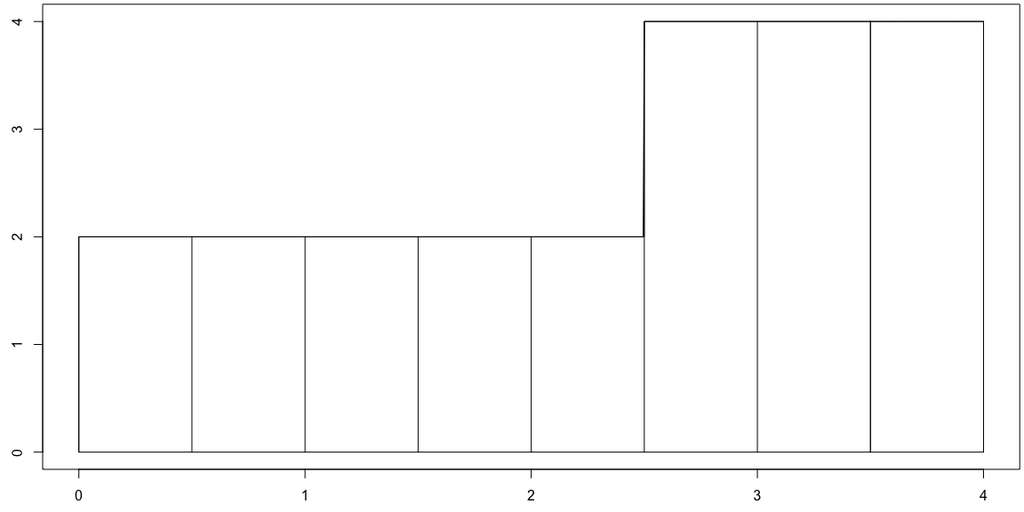

```r
f <- function(x){ifelse(x<2.5,2,4)}
draw_rect_approx(f,0,4,8)
```

We now use the same weighted average formula $\frac{\sum x_i A_i}{\sum A_i}$ to compute the $x$ coordinate of the centroid. The benefit of using equally spaced rectangles is that we have a simple formula for computing the area of each rectangle. Letting $x_i$ be the $x$-coordinate of the cetroid of each rectangle, we have $A_i = f(x_i) \Delta x$. The code below gives all of these values in a nice table.

```r
dx <- 0.5
xi <- seq(dx/2,4,dx)
Ai <- f(xi)*dx
tbl <- data.frame(x_i = xi, A_i = Ai)
kable(tbl, format = "html", align = "c")
```

| x_i | A_i |
| --- | --- |
| 0.25 | 1 |
| 0.75 | 1 |
| 1.25 | 1 |
| 1.75 | 1 |
| 2.25 | 1 |
| 2.75 | 2 |
| 3.25 | 2 |
| 3.75 | 2 |

```r
c(total_area =sum(Ai),
  expected_value = sum(xi*Ai)/sum(Ai))
```

```
##     total_area expected_value
##      11.000000       2.340909
```

The latter method, using rugs of equal width, allows us to use similar code, even if we doubled the number of rectangles. Note that this makes the width of each rectangle smaller, so for this example we’d have $\Delta x = 0.25$.

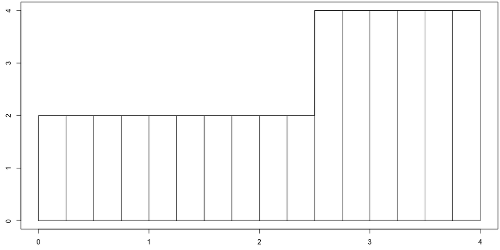

```r
draw_rect_approx(f,0,4,n=16)
```

```r
dx <- 0.25
xi <- seq(dx/2,4,dx)
Ai <- f(xi)*dx
tbl <- data.frame(x_i = xi, A_i = Ai)
kable(tbl, format = "html", align = "c")
```

| x_i | A_i |
| --- | --- |
| 0.125 | 0.5 |
| 0.375 | 0.5 |
| 0.625 | 0.5 |
| 0.875 | 0.5 |
| 1.125 | 0.5 |
| 1.375 | 0.5 |
| 1.625 | 0.5 |
| 1.875 | 0.5 |
| 2.125 | 0.5 |
| 2.375 | 0.5 |
| 2.625 | 1.0 |
| 2.875 | 1.0 |
| 3.125 | 1.0 |
| 3.375 | 1.0 |
| 3.625 | 1.0 |
| 3.875 | 1.0 |

```r
c(total_area =sum(Ai),
  expected_value = sum(xi*Ai)/sum(Ai))
```

```
##     total_area expected_value
##      11.000000       2.340909
```

Why care about adding more rectangles? The answer is because for just about anything that isn’t a rectangle, we can approximate with rectangles. In general, if there are $n$ rectangles between $a$ and $b$, then we have $\Delta x = \frac{b-a}{n}$. Let’s illustrate this using two examples we’ve already explored, namely the triangular rug, and rug under a parabola.

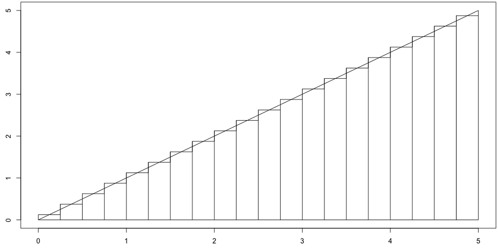

```r
f <- function(x){x}
a <- 0
b <- 5
n <- 20
dx <- (b-a)/n
draw_rect_approx(f,a,b,n)
```

```r
xi <- seq(a+dx/2,b,dx)
Ai <- f(xi)*dx
c(total_area =sum(Ai),
  expected_value = sum(xi*Ai)/sum(Ai))
```

```
##     total_area expected_value
##       12.50000        3.33125
```

For our parabola function, approximating the rug by using 50 rectangles instead, yields an expected value of 2.9997, which is only 0.0003 away from the actual value of $\mu = 3$.

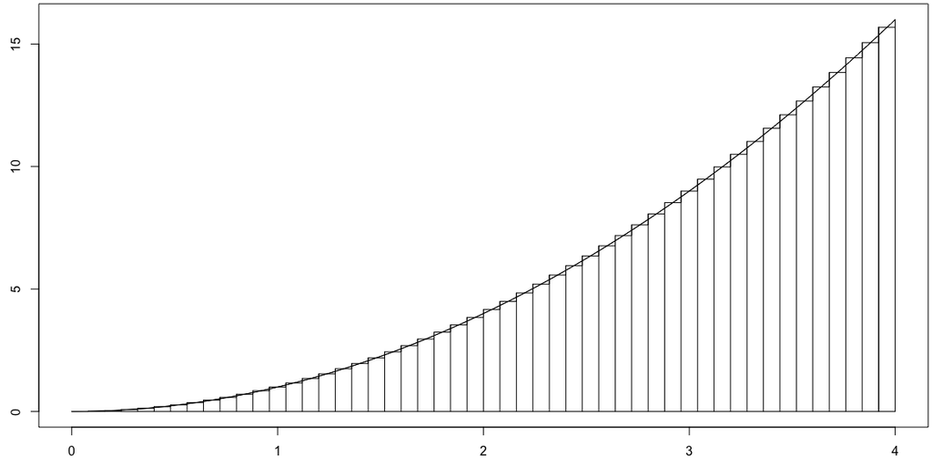

```r
f <- function(x){x^2}
a <- 0
b <- 4
n <- 50
dx <- (b-a)/n
draw_rect_approx(f,a,b,n)
```

```r
xi <- seq(a+dx/2,b,dx)
Ai <- f(xi)*dx
#data.frame(xi = xi, `f.xi` =f(xi), Ai = Ai, `xi.Ai` = xi*Ai )
c(total_area =sum(Ai),
  expected_value = sum(xi*Ai)/sum(Ai))
```

```
##     total_area expected_value
##        21.3312         2.9997
```

We’ll use the approach above to gives us a simple way to approximate area (probabilitiy) as well as expected value for any random variable, by just adding up the areas of the thin rectangles. If the approximation isn’t good enough, we increase the number of rectangles.

So how did people compute the expected value exactly? They took a limit as the number of rectangles increased to infinity. This process goes by the name of “Reimann Sums” and is the content of the next section.

## Day 4: Reimann Sums $\sum f(x_i) \Delta x$ and the Definite Integral $\int_a^b f(x)dx$

…. More to be added.

This section needs to have:

1. A formal limited definition of Reimann sums. We’ll focus on midpoints.
2. A formal limited definition of the definite integral.
3. Practice with computing both of the above.
4. Examples that include left or right sums.
5. Connect the definitions back to OpenStax.
6. Computations related to both area and expected value.
7. Computations requiring the students to compute $F(x)$ for specific values of a function. We WON’T be getting the general formula for $F(x)$ yet. We’ll let that appear when we get the fundamental theorem of calculus.
8. A definition of the Variance of a random varialble. Have them approximate one.
9. Do we want to provide them a reimann sum command? I’ll include it in the intial draft.

So this section is NOT about computing CDFs.